# Case Study 2

Pankaj Kumar, Brady Arendale, Kay Ayala

5/28/2020

# Introduction

We were tasked with analyzing results from the women’s portion of the annual Credit Union Cherry Blossom Ten Mile Run in Washington, D.C. We wanted to look at trends of things like age and completion times over the years.

# Scraping the Data

We used the Python package BeautifulSoup to scrape women’s race results from 1999-2012. There were challenges with inconsistent formatting of the results from year to year, which we handled by using conditional statements and running different code based on the year. The following code downloads results for each year, scrapes them into a dataframe, and cleans it up for plotting. Then it saves the resulting data frame to `processed_women.csv`.

```python
import re
from io import StringIO
import requests
from bs4 import BeautifulSoup
import pandas as pd
import urllib3
import os
import urllib
import re

#### From text
menURLs = [
    "results/1999/cb99m.html",
    "results/2000/cb003m.htm",
    "results/2001/oof_m.html",
    "results/2002/oofm.htm",
    "results/2003/CB03-M.HTM",
    "results/2004/men.htm",
    "results/2005/CB05-M.htm",
    "results/2006/men.htm",
    "results/2007/men.htm",
    "results/2008/men.htm",
    "results/2009/09cucb-M.htm",
    "results/2010/2010cucb10m-m.htm",
    "results/2011/2011cucb10m-m.htm",
    "results/2012/2012cucb10m-m.htm"]


womenURLs = [
    "results/1999/cb99f.html",
    "results/2000/cb003f.htm",
    "results/2001/oof_f.html",
    "results/2002/ooff.htm",
    "results/2003/CB03-F.HTM",
    "results/2004/women.htm",
    "results/2005/CB05-F.htm",
    "results/2006/women.htm",
    "results/2007/women.htm",
    "results/2008/women.htm",
    "results/2009/09cucb-F.htm",
    "results/2010/2010cucb10m-f.htm",
    "results/2011/2011cucb10m-f.htm",
    "results/2012/2012cucb10m-f.htm"]

## columns with same meaning but different names will be mapped to just one
columns_dict = {'AG': 'AGE',
'Ag':'AGE',

'GUN': 'GUN_TIME',
'GUN TIM':'GUN_TIME',
'Gun':'GUN_TIME',
'Gun Tim':'GUN_TIME',

'HOMETOWN': 'HOMETOWN',
'Hometown':'HOMETOWN',

'NAME': 'NAME',
'Name': 'NAME',

'NET':'TIME',
'NET TIM':'TIME',
'Net':'TIME',
'Net Tim':'TIME',
'Net Tim  ':'TIME',
'TIME':'TIME',
'Time':'TIME'}

ubase = "http://www.cherryblossom.org/"
data_home = r'./race_data'
```

```python
def scrap_runs(urls, gender):
    for rel_url in urls:
        url = urllib.parse.urljoin(ubase, rel_url)
        year = re.search('/(\d{4})', url)[0][1:]
        print("scrapping data from {} for {}".format(url, gender))
        response = requests.get(url)
        soup = BeautifulSoup(response.content)
        if year == '2000':
            result = soup.find(face="Courier New").get_text()
        ## there us some special handling for men data for year 2000
        elif year == '2009' and gender == 'men':
            result = soup.find(class_="Section1").get_text()
        else:
            result = soup.find('pre').get_text()
        with open(os.path.join(data_home, '{}_{}.txt'.format(gender, year)),
                  'w+') as f:
            ## for year 2001 headers are not present for women's result. adding them explicitly
            if year == '2001' and gender == 'women':
                f.writelines('PLACE DIV   NAME                  AG HOMETOWN           GUN TIM  NET TIM\n')
                f.writelines('===== ===== ===================== == ================== =======  =======\n')
            f.writelines(result)
```

```python
def create_df(gender):
    final_file_path = os.path.join(data_home,'final_{}.csv'.format(gender))

    all_columns = set()
    all_dfs = {}
    for year in range(1999, 2013):
        print("processing file for year {} gender {}".format(year, gender))
        with open(os.path.join(data_home, '{}_{}.txt'.format(gender, year)), 'r') as f:
            lines = f.readlines()
            for idx, line in enumerate(lines):
                if line.startswith('='):
                    print(year, line)
                    # split on   line starting with =  to determine width of data
                    w = [len(s) + 1 for s in line.split(" ")]
                    df = pd.read_fwf(StringIO("\n".join(lines[(idx - 1):])), widths=w)
                    df.dropna(axis=0, how='all', inplace=True)
                    all_dfs[year] = df
                    all_columns.update(df.columns)
                    ## usually either net time ot time is present in data. for 2011 women both columns are
                    #present with duplciate values. dropping one of them
                    #if gender =='women' and year ==2011:
                        #df.drop('Time', axis=1, inplace=True)

    cleaned_df = []
    for key in all_dfs.keys():
        df = all_dfs[key]
        adf = df.rename(dict(zip(df.columns, [x.strip() for x in df.columns])), axis=1)
        cols = {x: columns_dict[x] for x in adf.columns if x in columns_dict}
        adf = adf.rename(cols, axis=1)
        adf = adf[~adf['NAME'].str.startswith('==')]
        ## adding year column so that we can create one dataframe in the end
        adf['YEAR'] = int(key)
        cleaned_df.append(adf)
    final_df = pd.concat(cleaned_df)[['YEAR', 'NAME', 'AGE', 'TIME', 'GUN_TIME', 'HOMETOWN']]
    final_df.to_csv(final_file_path)
    return final_file_path


def convert_to_float (str):
    try:
        return float(str)
    except :
        return 0
```

```python
gender = 'women'
scrap_runs(womenURLs, gender)
final_file_path = create_df(gender)
processed_file = os.path.join(data_home,'processed_{}.csv'.format(gender))
df = pd.read_csv(final_file_path)
df['AGE'] =  df.AGE.apply(convert_to_float)
df['AGE'].fillna(0, inplace=True)
df['TOTAL_TIME'] =  df['TIME'].fillna(df['GUN_TIME'])
df.to_csv(processed_file)
```

# Analysis

We will now load our created csv file into R for plotting and analysis. First we do some more cleanup, as shown in the code below.

```r
library(ggplot2)

race <- read.csv("F:/SMU/Quantifying the World/qtw/case_study2/race_data/processed_women.csv", na.strings=c("","#"), stringsAsFactors = FALSE)

# Clean up TOTAL_TIME column
# Remove *, #, and letters from times
race$TOTAL_TIME <- gsub("[*#]", "", race$TOTAL_TIME)
race$TOTAL_TIME <- gsub("[A-Za-z]", NA, race$TOTAL_TIME)
# Get rows with only one colon in TOTAL_TIME (less than one hour)
ind <- which(lengths(regmatches(race$TOTAL_TIME, gregexpr(":", race$TOTAL_TIME)))==1)
# Add 0: to beginning of times
race[ind,"TOTAL_TIME"] <- paste("0:", race[ind,"TOTAL_TIME"], sep="")
# Add proper hour number to beginning of 2001 times
race[(18+4523):(2768+4523),"TOTAL_TIME"] <- paste("1", race[(18+4523):(2768+4523),"TOTAL_TIME"], sep="")
race[(2769+4523):(2972+4523),"TOTAL_TIME"] <- paste("2", race[(2769+4523):(2972+4523),"TOTAL_TIME"], sep="")
# Remove rows that are not racers
race <- race[!(race$AGE==0 & is.na(race$TOTAL_TIME)),]
# Set age values of 0 to NA
race[race$AGE==0,"AGE"] <- NA
# Change year to a factor
race$YEAR <- as.factor(race$YEAR)
# Change TOTAL_TIME to difftime format
race$TOTAL_TIME <- as.difftime(race$TOTAL_TIME)
```

## Age distribution by year

Let’s examine the distribution of age by year:

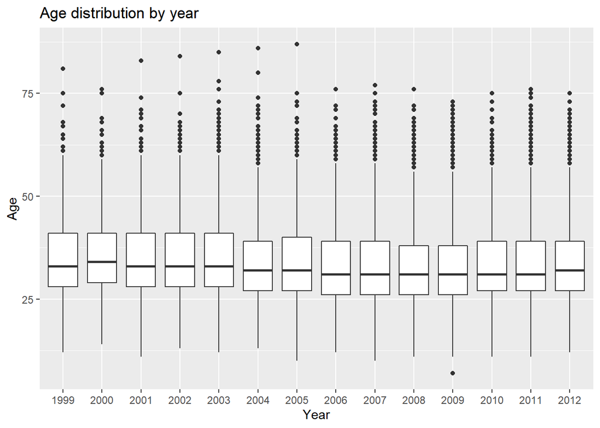

```r
ggplot(race, aes(x= YEAR, y= AGE)) + geom_boxplot() +
  labs(x="Year", y="Age", title="Age distribution by year")
```

We see that age distribution is very similar from year to year. The median age was slightly higher in the earlier years. Now let’s look at the density estimates for each year.

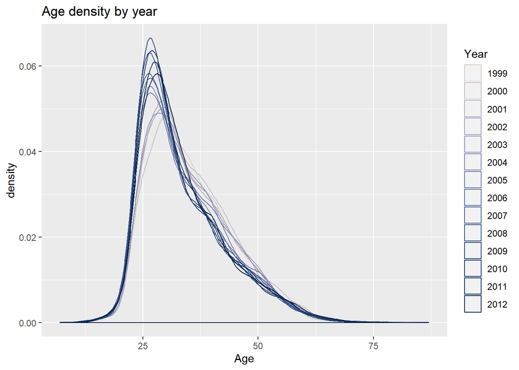

```r
plot_colors = c("#D8CAC3","#C5BCC2","#B2ADBF","#9F9FBB",
                "#8D91B5","#7B84AE","#6A76A5","#58699B","#485D90",
                "#385083","#294476","#1A3867","#0B2D58","#002248")
ggplot(race, aes(x= AGE , color = YEAR)) + geom_density() +
  scale_color_manual(values = plot_colors) +
  labs(x="Age", color="Year", title="Age density by year")
```

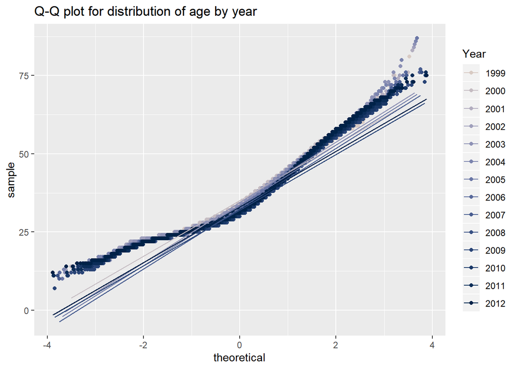

```r
ggplot(race, aes(sample = AGE, color = YEAR)) + stat_qq() + stat_qq_line() +
  scale_color_manual(values = plot_colors) +
  labs(color="Year", title="Q-Q plot for distribution of age by year")
```

The Q-Q plot also shows the gradual change in skewness over the years. Let’s break age into groups and see where the change is coming from.

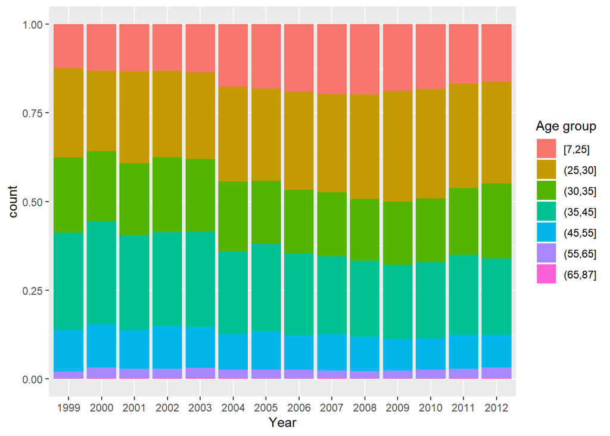

```r
race$age_group <- cut(race$AGE, c(7,25,30,35,45,55,65,87), include.lowest = T)
ggplot(race[!is.na(race$age_group),], aes(x=YEAR, fill=age_group)) + geom_bar(position = "fill") +
  labs(x="Year", fill="Age group")
```

There is a large increase in the proportion of entrants 25 and under in recent years making up for part of the shift in the distributions over the years. There is also a notable increase in the 26-30 age group, and a decrease in the 35-45 age group.

## Finish time by year

Since we have race times for several years, we thought it would be interesting to see how finish times have changed over the years. Let’s take a look:

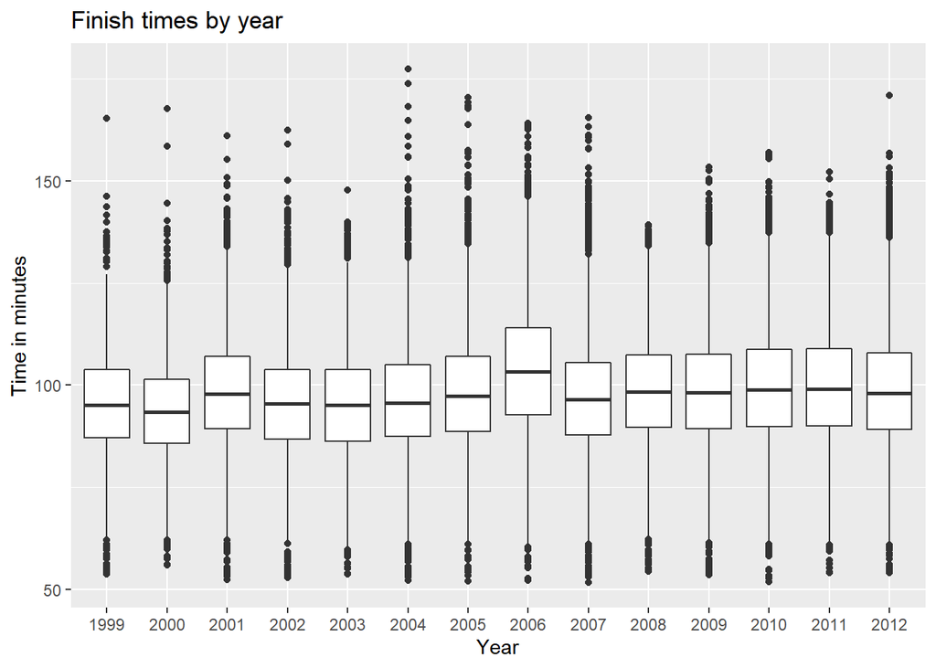

```r
ggplot(race, aes(x=YEAR, y=TOTAL_TIME)) + geom_boxplot() +
  labs(x="Year", y="Time in minutes", title="Finish times by year")
```

Average finish times have trended a bit upwards from year to year. This could be due to differences in age distribution, or it could be from more casual runners entering. Let’s look at the distribution of finish times by age group.

## Finish time by age group

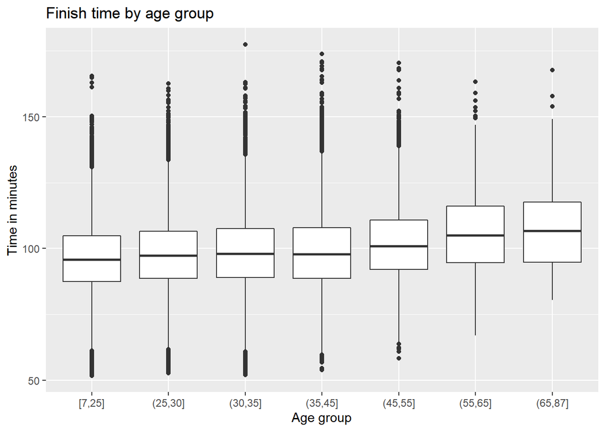

```r
ggplot(race[!is.na(race$age_group),], aes(x=age_group, y=TOTAL_TIME)) + geom_boxplot() +
  labs(x="Age group", y="Time in minutes", title="Finish time by age group")
```

Unsurprisingly, finish times are higher on average for older age groups. This makes it more likely that the difference in finish times is caused by an increase in the number of people who only run or jog casually. We can see the increase in number of participants here:

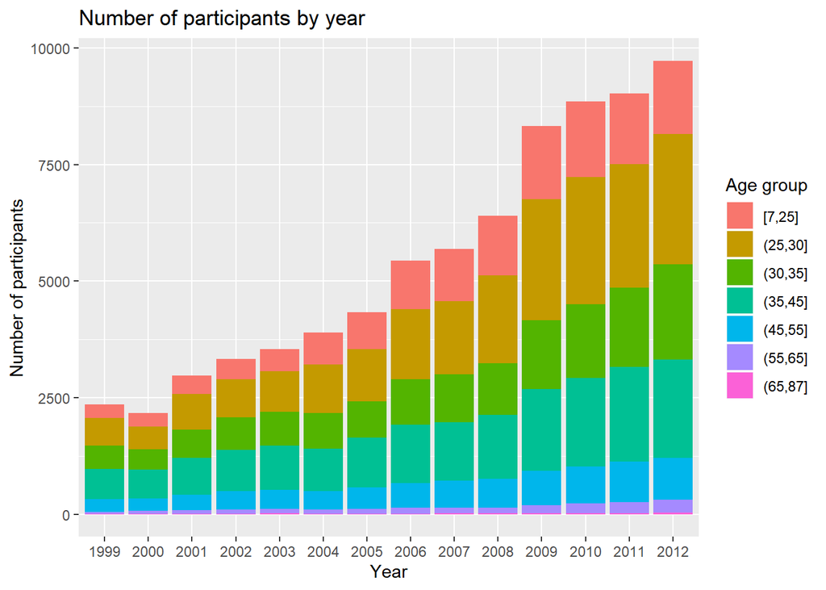

```r
ggplot(race[!is.na(race$age_group),], aes(x=YEAR, fill=age_group)) + geom_bar() +
  labs(x="Year", y="Number of participants", fill="Age group", title="Number of participants by year")
```